# (Investigation of Divvy bicycle sharing service dataset)

# (The effect gender, Age and weekdays on Trip duration )

## by (Hany Aly Elmogey)

## Investigation Overview

> I wanted to check what are the features that affect the trip duration the most.

## Dataset Overview

> This data set includes information about individual rides made in a bike-sharing system. I downloaded datasets for two consecutive years 2014 and 2015. Variables: trip_id: ID attached to each trip taken  
> starttime: day and time trip started, in CST  
> stoptime: day and time trip ended, in CST  
> bikeid: ID attached to each bike  
> tripduration: time of trip in seconds  
> from_station_name: name of station where trip originated  
> to_station_name: name of station where trip terminated  
> from_station_id: ID of station where trip originated  
> to_station_id: ID of station where trip terminated  
> usertype: "Customer" is a rider who purchased a 24-Hour Pass; "Subscriber" is a rider who purchased an Annual Membership  
> gender: gender of rider  
> birthyear: birth year of rider link to the datasets files " https://divvy-tripdata.s3.amazonaws.com/index.html" For more information, visit http://DivvyBikes.com/data or email questions to data@DivvyBikes.com.

## Although males used the bikes more than females but the average trip duration for females is higher than males

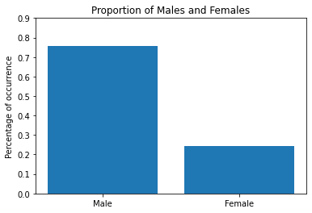

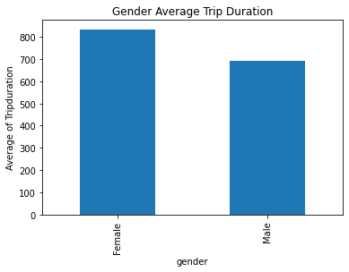

## Most of the users are in the Age group of 2 to 40 but age group 70 to 80 has the higest trip duration average

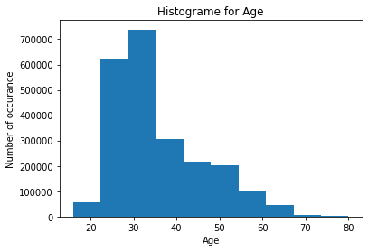

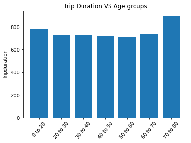

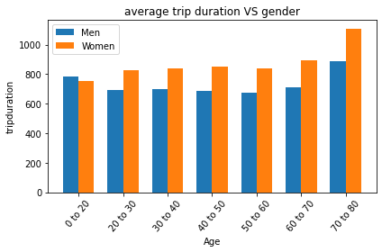

## The winter is the least season in the demand on bikes.

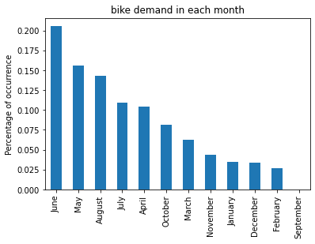

## Weekends have the heigest average trip duration.

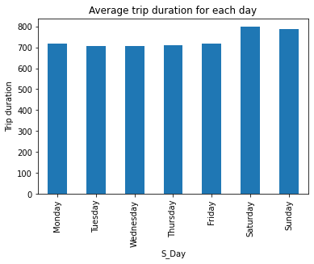

### The femails dominant the average trip duration.

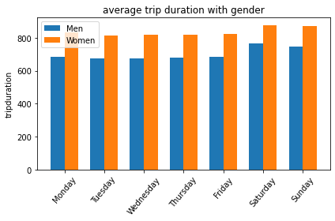